# Bank Customer Churn Analysis Using Support Vector Machine

Gopi Shankar Mallu

Vamsi Kalla

Dinesh Donkada

Kavya Maale

2024-04-15

# Introduction

Support Vector Machines (SVMs) are powerful supervised learning models used for both classification and regression tasks. By constructing a hyperplane in a high-dimensional space, SVMs achieve class separation by maximizing the margin between the closest data points of each class. This approach not only enhances the model’s accuracy but also its predictive reliability across datasets with numerous features or clear separations between classes.

## Hyperplanes

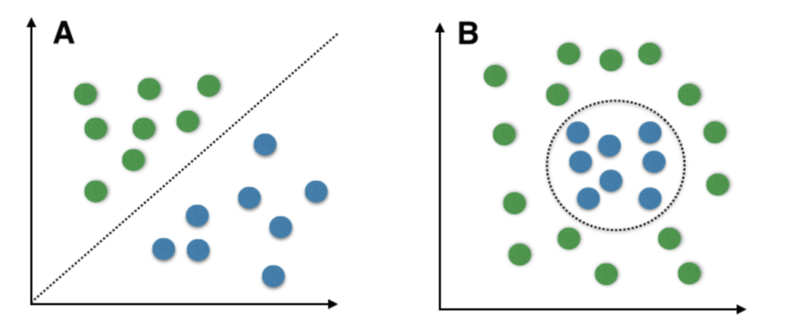

- Hyperplanes are decision boundaries that help classify the data points. Data points falling on either side of the hyperplane can be attributed to different classes. Also, the dimension of the hyperplane depends upon the number of features.

- **Image A** shows a clear linear separation, demonstrating the SVM hyperplane in a scenario where data is linearly separable.**Image B** illustrates data that is not linearly separable in its original space but can be tackled by SVM through the use of a kernel function.

# Methodology

- Support Vector Machines (SVMs) serve as a robust methodology for binary classification by creating a hyperplane which acts as a decision boundary between two classes. This hyperplane is determined mathematically by the equation $w^T.x +b=0$, where $w$ is the weight vector perpendicular to the hyperplane, and $b$ is the bias, shifting the hyperplane away from the origin.

### **kernel function in SVM**

- In Support Vector Machines (SVM), the kernel function plays a crucial role in transforming the input feature space into a higher-dimensional space where the data can be linearly separated. This is particularly useful in cases where the data is not linearly separable in its original space. The kernel function computes the dot product between the feature vectors in this higher-dimensional space without explicitly mapping the vectors into that space, which is known as the “kernel trick.”
- **Common types of kernel functions include:**
- **Linear Kernel**: $K(w,b)=w^Tx+b$. This is the simplest form of the kernel, used when the data is linearly separable.
- **Polynomial Kernel**: $K(w, b) = (1 + w^T.x b)^d$. This kernel maps the input features into a polynomial feature space, allowing for polynomial decision boundaries.
- **Radial Basis Function (RBF) Kernel**: $K(w, b) = \exp(-\gamma |w.x - b|^2)$. Also known as the Gaussian kernel, it maps the features into an infinite-dimensional space, providing a lot of flexibility for non-linear decision boundaries.
- Each kernel function has its own set of parameters that need to be tuned for optimal performance. The choice of kernel function and its parameters can significantly impact the SVM model’s ability to capture the underlying patterns in the data.

## SVM’s Objective Function and Optimaztion

The objective function that SVM optimizes is a combination of maximizingthe margin and minimizing the classification error. This is achievedthrough the minimization of the following objective function:
$$min_{w, b} \frac{1}{2} \|w\|^2 + C \sum_{i=1}^{n} \xi_i$$
Subject to the constraints:
$$y_i (w^T x_i + b) \geq 1 - \xi_i \quad \text{and} \quad \xi_i \geq 0 \quad \text{for all } i$$
where $w$ is the weight vector, $b$ is the bias term, $C$ is theregularization parameter, $\xi_i$ are the slack variables representingthe degree of misclassification of the $i$-th data point, and $y_i$ arethe class labels.

### **Hinge Loss**

- The hinge loss function is used in SVM to penalize misclassifications. It is defined as: **Hinge loss** = $\max(0, 1 - y_i (w^T x_i + b))$ The hinge loss is zero for correctly classified points that are outside the margin, and it increases linearly for points that are on the wrong side of the hyperplane or within the margin.
- The optimization of the objective function involves finding the values of $w$ and $b$ that minimize the function, subject to the constraints. This is typically done using quadratic programming techniques.

# Objective

The main objective of this project is to utilize the Support Vector Machine (SVM) algorithm to effectively predict customer churn at ABC Multinational Bank. This predictive model aims to identify key indicators that signal the likelihood of customers opting to leave the bank. By understanding these indicators, the bank can deploy targeted interventions to improve customer satisfaction and retention. Ultimately, this effort will enable ABC Multinational Bank to take proactive measures in retaining valuable customers, thereby stabilizing their customer base and enhancing long-term business sustainability.

# Analysis and Modelling

## Data Description

| Column Name | Description |
| --- | --- |
| `customer_id` | A unique identifier for each customer, not used in the analysis. |
| `credit_score` | A numerical representation of the customer’s creditworthiness. |
| `country` | The country in which the customer resides. |
| `gender` | The gender of the customer (e.g., male, female). |
| `age` | The age of the customer in years. |
| `tenure` | The number of years the customer has been with the bank. |
| `balance` | The current balance in the customer’s account. |
| `products_number` | The number of products the customer has with the bank. |
| `credit_card` | Indicates whether the customer has a credit card with the bank. |
| `active_member` | Indicates whether the customer is an active member. |
| `estimated_salary` | The estimated annual salary of the customer. |
| `churn` | The target variable, indicating customer churn (1 for churned, 0 for not churned). |

## Exploratory Data Analysis

- Data dimesions
- Summary Statistics
- Null Values
- Categorical Variables

This dataset consists of 14 columns and 165034 rows.

```
[1] 165034     14
```

```
  CreditScore         Age            Tenure         Balance
 Min.   :350.0   Min.   :18.00   Min.   : 0.00   Min.   :     0
 1st Qu.:597.0   1st Qu.:32.00   1st Qu.: 3.00   1st Qu.:     0
 Median :659.0   Median :37.00   Median : 5.00   Median :     0
 Mean   :656.5   Mean   :38.13   Mean   : 5.02   Mean   : 55478
 3rd Qu.:710.0   3rd Qu.:42.00   3rd Qu.: 7.00   3rd Qu.:119940
 Max.   :850.0   Max.   :92.00   Max.   :10.00   Max.   :250898
 NumOfProducts   EstimatedSalary
 Min.   :1.000   Min.   :    11.58
 1st Qu.:1.000   1st Qu.: 74637.57
 Median :2.000   Median :117948.00
 Mean   :1.554   Mean   :112574.82
 3rd Qu.:2.000   3rd Qu.:155152.47
 Max.   :4.000   Max.   :199992.48
```

```
             id      CustomerId         Surname     CreditScore       Geography
              0               0               0               0               0
         Gender             Age          Tenure         Balance   NumOfProducts
              0               0               0               0               0
      HasCrCard  IsActiveMember EstimatedSalary          Exited
              0               0               0               0
```

There are no null values in the dataset.

```
     Geography         Gender      HasCrCard IsActiveMember         Exited
             3              2              2              2              2
```

- **Geography:** Geography column have 3 uniques values Framce, Germany, Spain
- **Gender:** Gender column have 2 unique values Male, Female
- **IsActiveMember:** Column consists of 2 unique values yes and no
- **HasCrCard:** Column consists o 2 unique values yes or no indicating is user have credit card or not.
- **Exited:** This is a target column which indicates weather the customer is exited the bank or not

## Data Visualization

- Age Distribution
- Geographical Variation in Product Distribution
- Churn Rate by Geography
- Correlation Plot

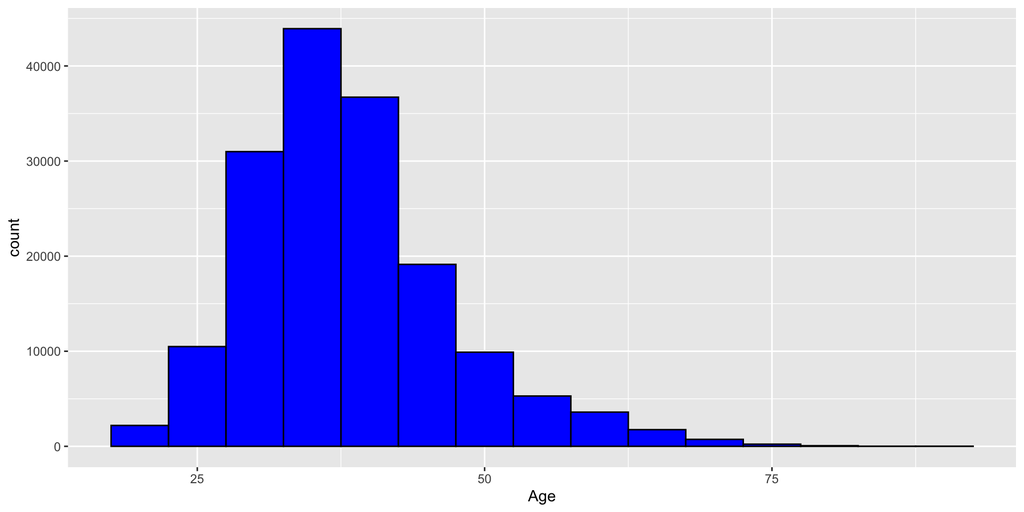

**Observations:**

The largest concentration of customers falls within the 30 to 40-year-old range, indicating that the majority of customers are in their early to mid-career stages.

There is a significant drop in frequency as age increases, especially beyond 50 years. This suggests that the customer base skews younger.

The distribution is right-skewed, meaning there are fewer older customers (those over 60) compared to younger customers.

There is a small number of customers in the youngest age bracket (under 25 years) and the oldest (over 75 years).

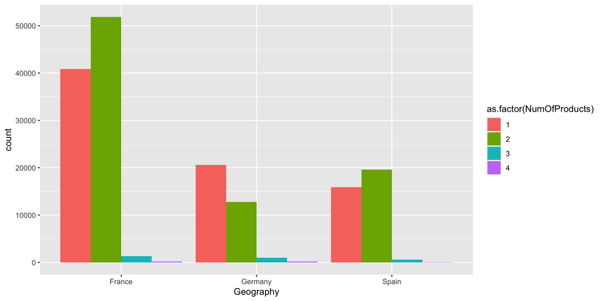

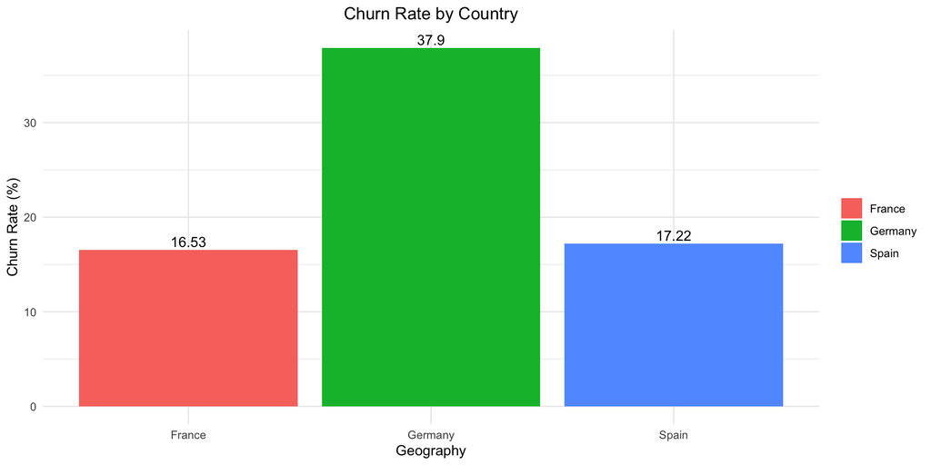

**Observations:**

The highest churn rate is in Germany(37.9%) followed by Spain(17.22%) and least in France(16.53%)

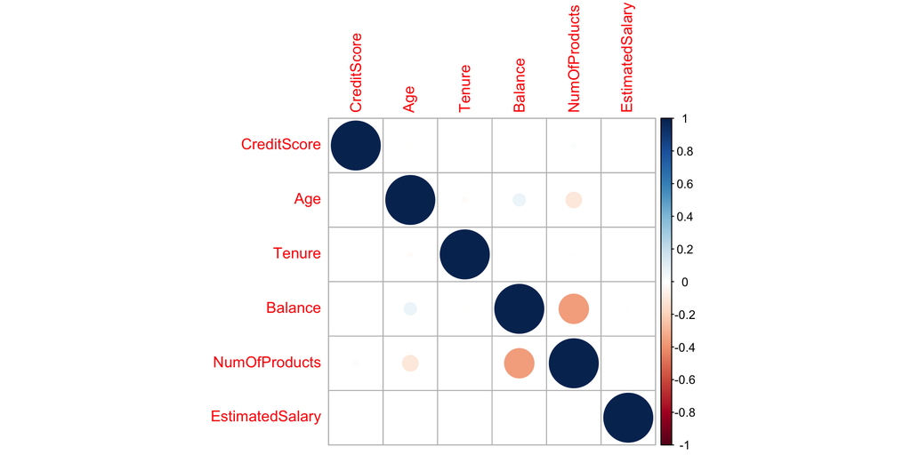

**Observations:**

## Data preparation for modelling

- One Hot & Label Encoding
- Data Splitting & Handling Imbalance.
- Data Normalization.

**One Hot Encoding:** As geography is categorical column so we have performed one hot encoding to convert in to numerical coulmns for each value type.

**Label Encoding:** Peformed Label encoding on Gender and Exited column to convert them to numerical columns.

We split our data into training and testing sets using 70-30 rule to evaluate the performance of our models on unseen data.

To address class imbalance in our target variable, we employed the Synthetic Minority Over-sampling Technique (SMOTE), which helped create a more balanced distribution of classes

Normalization is a crucial preprocessing step that helps in standardizing the data values within a specific range, typically zero mean and unit variance. This is particularly important for algorithms that assume data is normally distributed, or for those that are sensitive to the scale of the input features, such as Support Vector Machines or k-nearest neighbors.

In normalization we have calculated the mean and standard deviation for selected numerical columns in the training data, using the apply function in R to avoid data leakage from the test set. The training data is then standardized by subtracting the mean and dividing by the standard deviation for each column, a method known as Z-score normalization. This same scaling approach is applied to the test set to ensure both datasets are on a comparable scale, facilitating more accurate model training and evaluation.

## Statistical Modelling

In this modeling phase, two different machine learning models are trained for a classification task using the caret package in R. The models include Support Vector Machine (SVM) with a radial basis function kernel and the Random Forest model.

The target variable Exited is converted to a factor to ensure that it is treated as a categorical variable for classification. A consistent seed (set.seed(123)) is set before training each model to ensure reproducibility of the results.

The trainControl function is used to set up the training control parameters, specifying 5-fold cross-validation (method = “cv”) to assess the performance of the models.

For the SVM model, data preprocessing steps (preProcess = c(“center”, “scale”)) are included to center and scale the features, which is often necessary for SVM models to perform well.

Each model is trained on the train_balanced dataset using the train function from the caret package, with the model type specified by the method parameter (“svmRadial” for SVM and “rf” for Random Forest).

The trained models are tested on Test set and compared the performances of both models

# Results

| Metric | SVM | Random Forest |
| --- | --- | --- |
| Accuracy | 79.52% | 83.38% |
| Kappa | 0.494 | 0.5375 |
| Sensitivity | 79.11% | 86.48% |
| Specificity | 81.09% | 71.70% |
| Positive Predictive Value | 94.02% | 91.99% |
| Negative Predictive Value | 50.82% | 58.54% |
| Balanced Accuracy | 80.10% | 79.09% |
| AUC-ROC | 0.801 | 0.791 |

# Conclusion

In this analysis of bank customer churn prediction, the Support Vector Machine (SVM) model has shown promising results, particularly in terms of specificity (81.09%) and positive predictive value (94.02%). These metrics are crucial in the banking context, as they indicate the model’s accuracy in correctly identifying loyal customers (specificity) and its reliability in flagging potential churners (positive predictive value). Additionally, the SVM model’s highest AUC-ROC score of 0.801 underscores its effectiveness in distinguishing between customers who are likely to churn and those who are not across various decision thresholds.